# Final Project Presentation

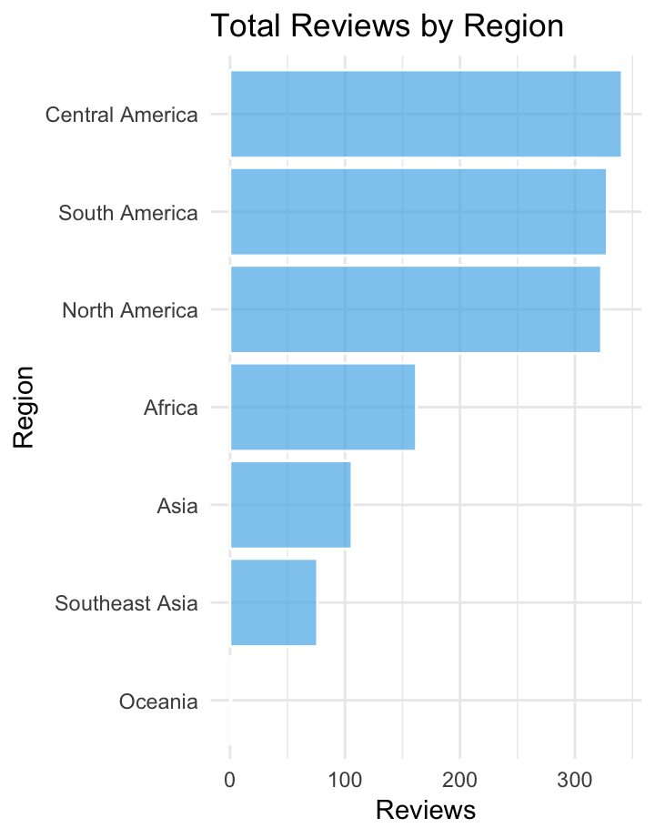

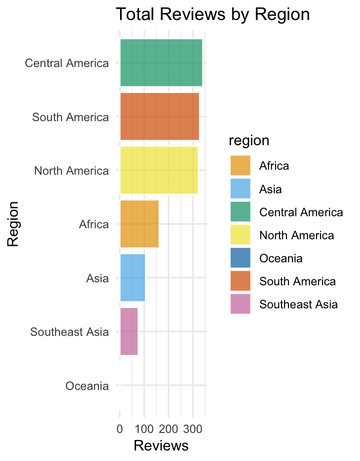

[figure not shown]

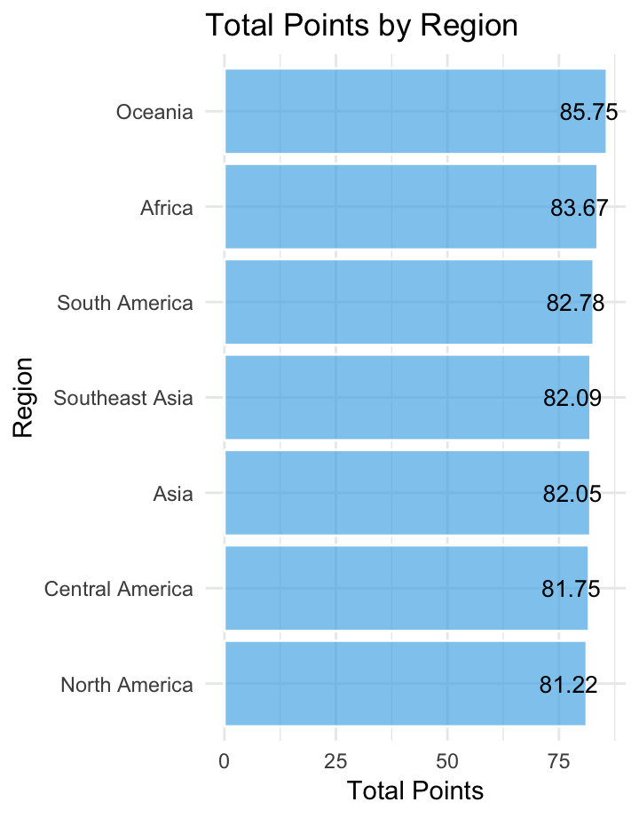

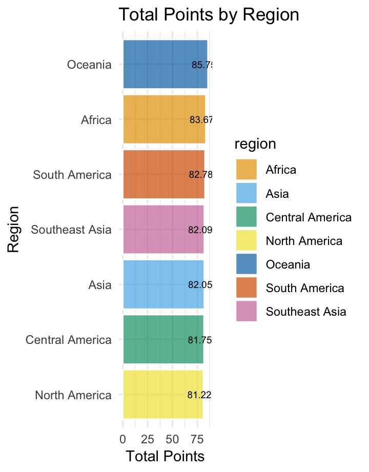

[figure not shown]

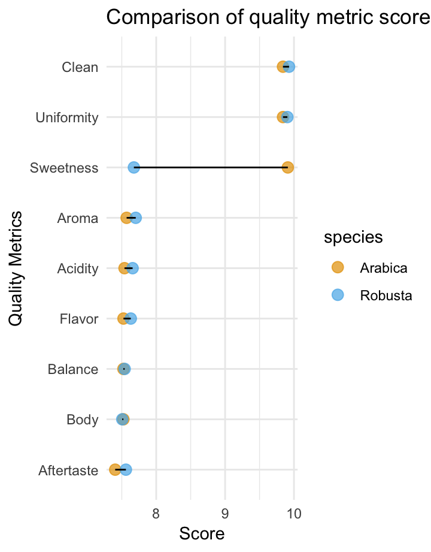

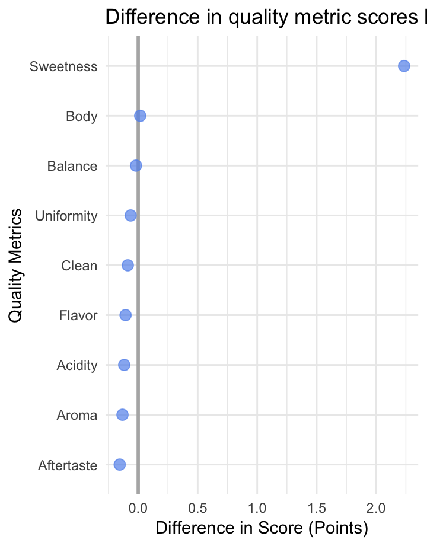

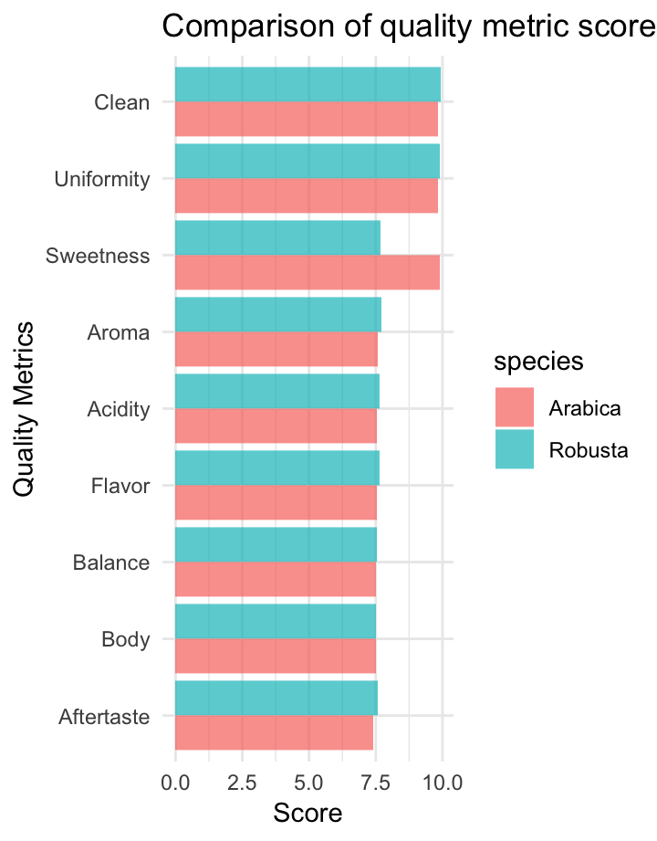

# Visualization 1

### Final Version

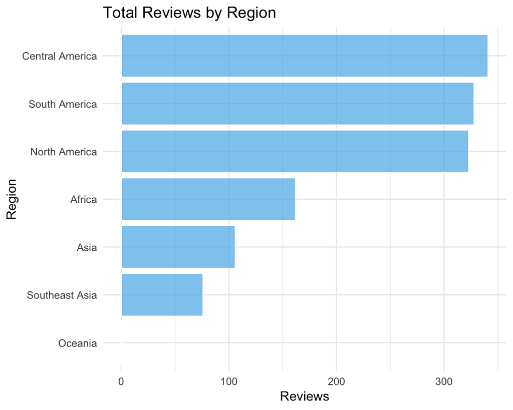

> The final version of the plot is the most minimal and succinct representation of the coffee reviews. I think that this version has the least cognitive load for the general audience. The histogram will hopefully assist coffee lovers with general guidelines for the popularity/reputation and distribution of various world regions.

### Version 2

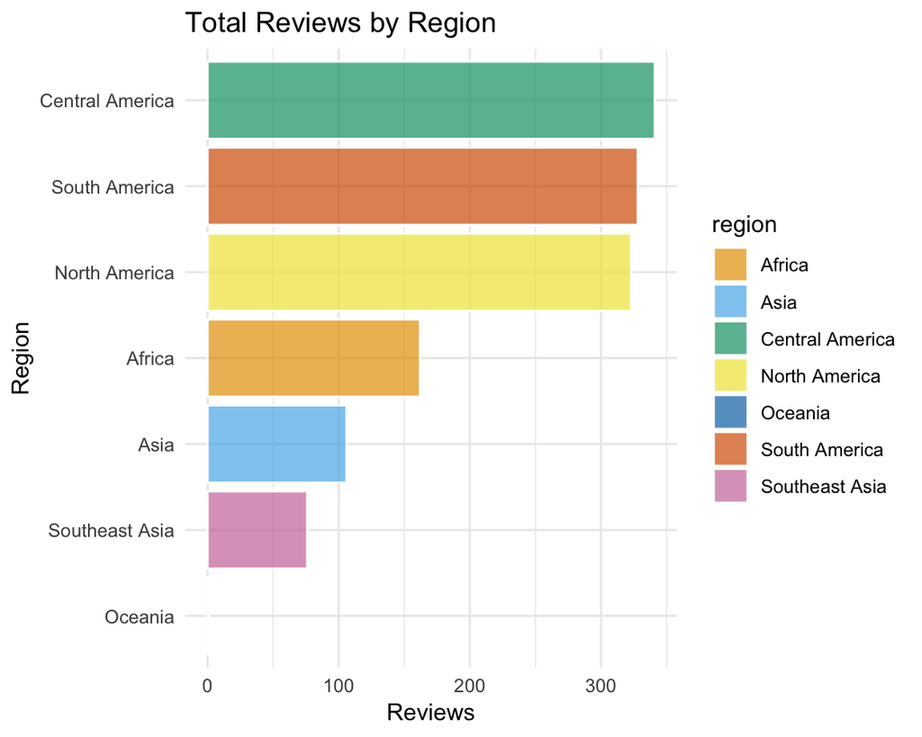

> I believe this plot is a definite upgrade, but I decided that the legend and fill were superfluous.

### Version 1

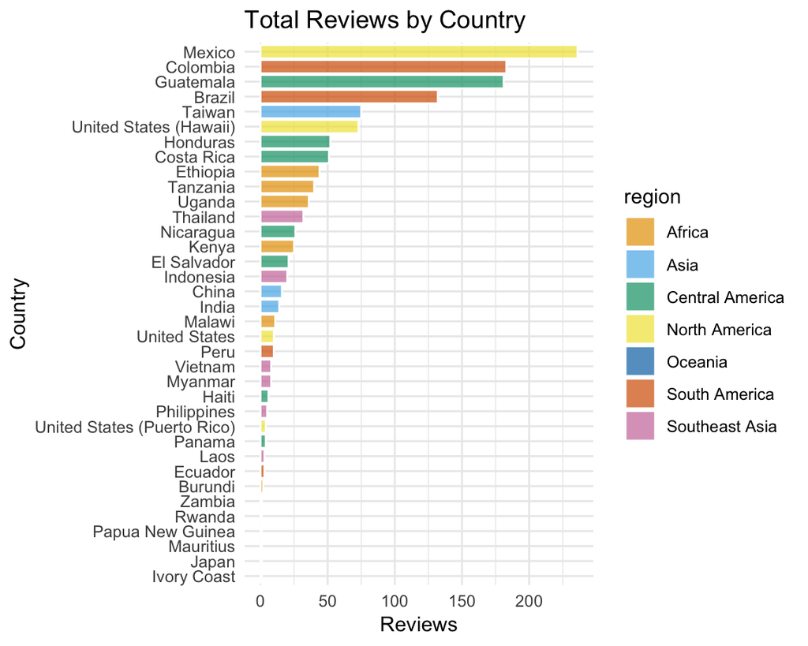

> The plot is a nice portrayl of individual countries, but I think the information can be more clearly communicated in a concicse manner.

# Visualization 2

### Final Version

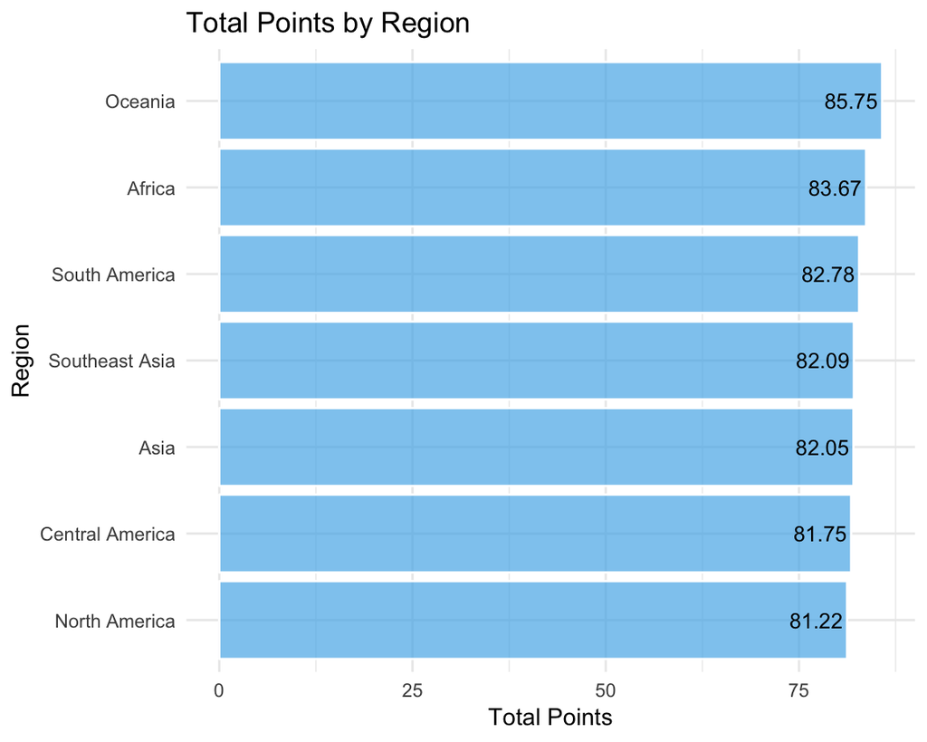

> Similar to the first visualization, this plot is most easily understood as a minimal representation of the data. At the recommendation of my peer reviewers, I removed the legend and Okabe Ito fill to improve clarity. The plot is meant as a companion piece to the first visualization, providing a general audience broad insight into regional coffee quality.

### Version 2

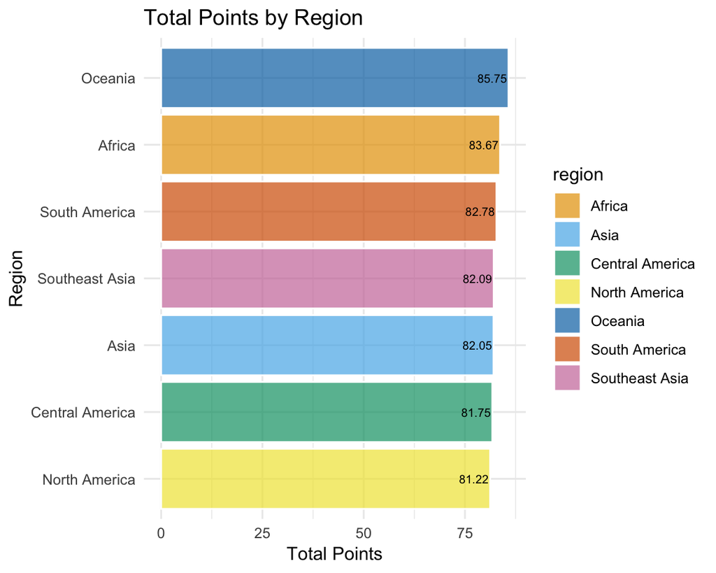

> This plot condensed the countries into broad world regions, which helps simplify the overall purpose/message. However, there is still more to be removed from this plot without compromising the clairty.

### Version 1

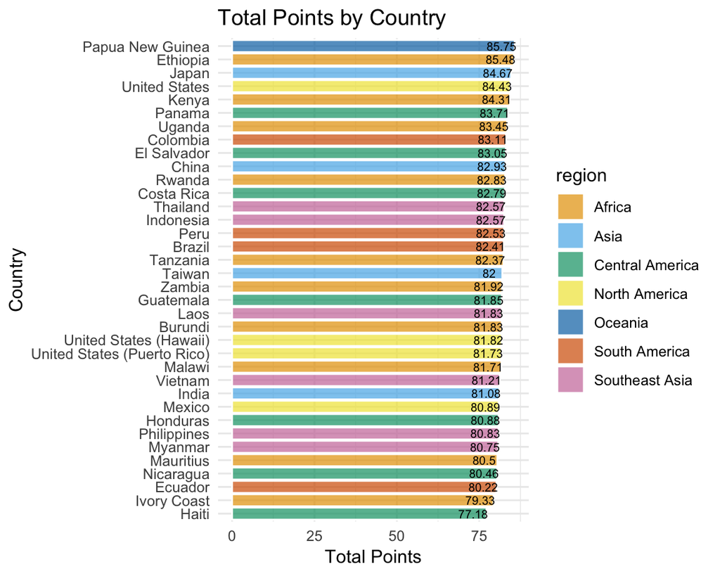

> A good initial effort, but I can definitely improve upon it! Since there are no clear trends in world region, I believe that I can collapse the data to world regions.

# Visualization 3

### Final Version

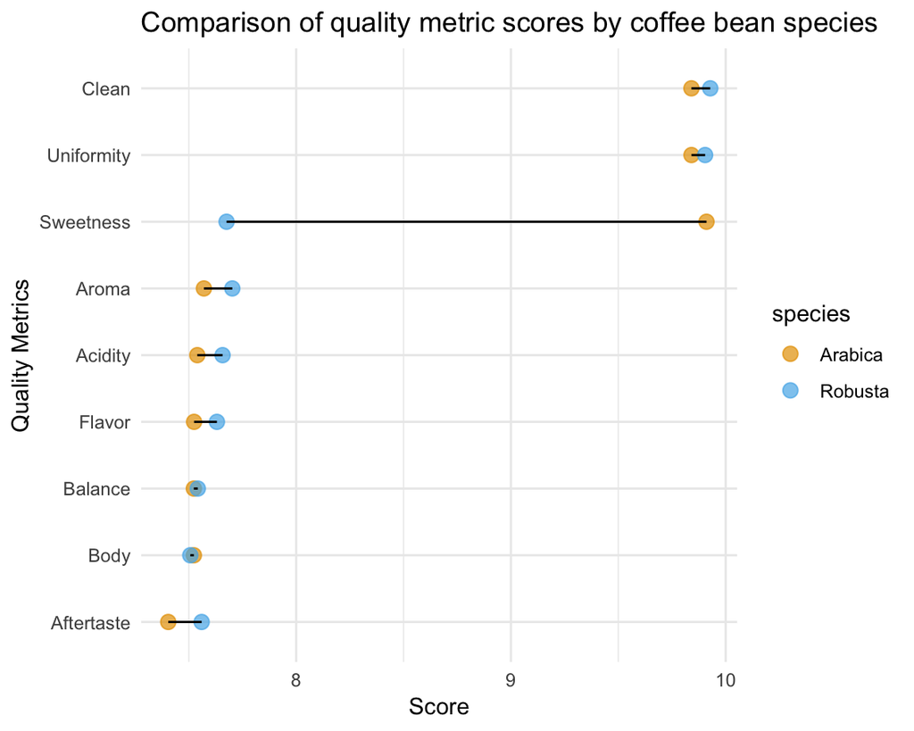

> The final version of this plot most clearly portrays the difference in inidividual quality metric scores. This is especially evidence in the sweetness metric, which has the longest line between point totals. This plot has a broad appeal, and can provide useful information to both a general audience as well as professional coffee organizations. Interestingly, despite numerous reports, these two species are remarkably similar across all quality metrics other than sweetness.

### Version 2

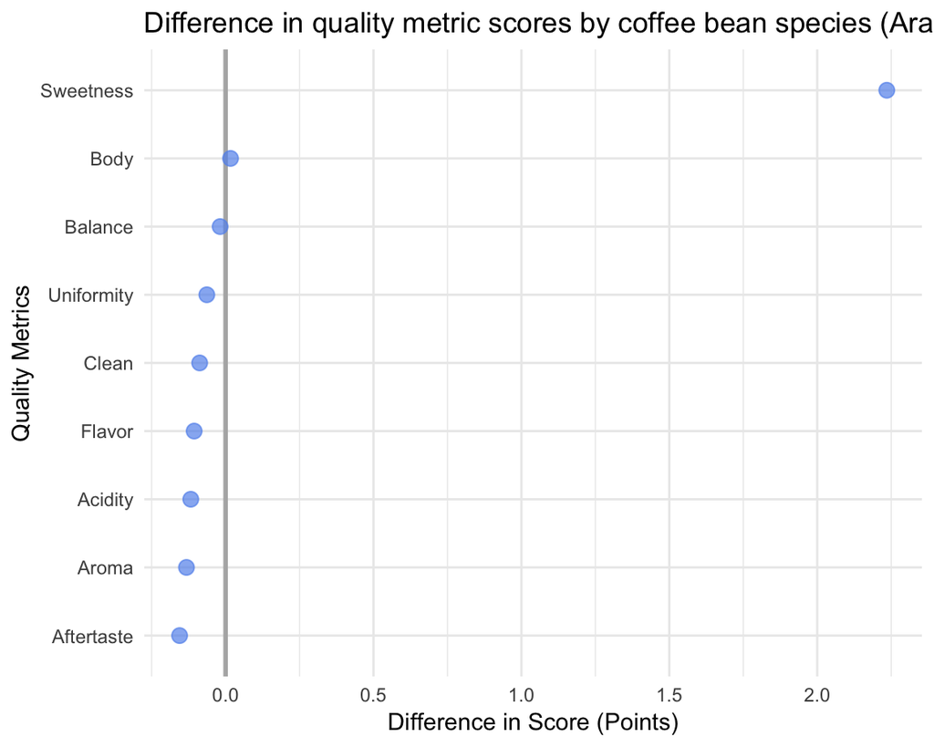

> This plot is a significant departure from the earlier version, focusing on the difference in point totals between the two bean species. Although the difference in sweetness scores is more visible, I think that this plot is less convincing/clear overall. There is still more work to be done!

### Version 1

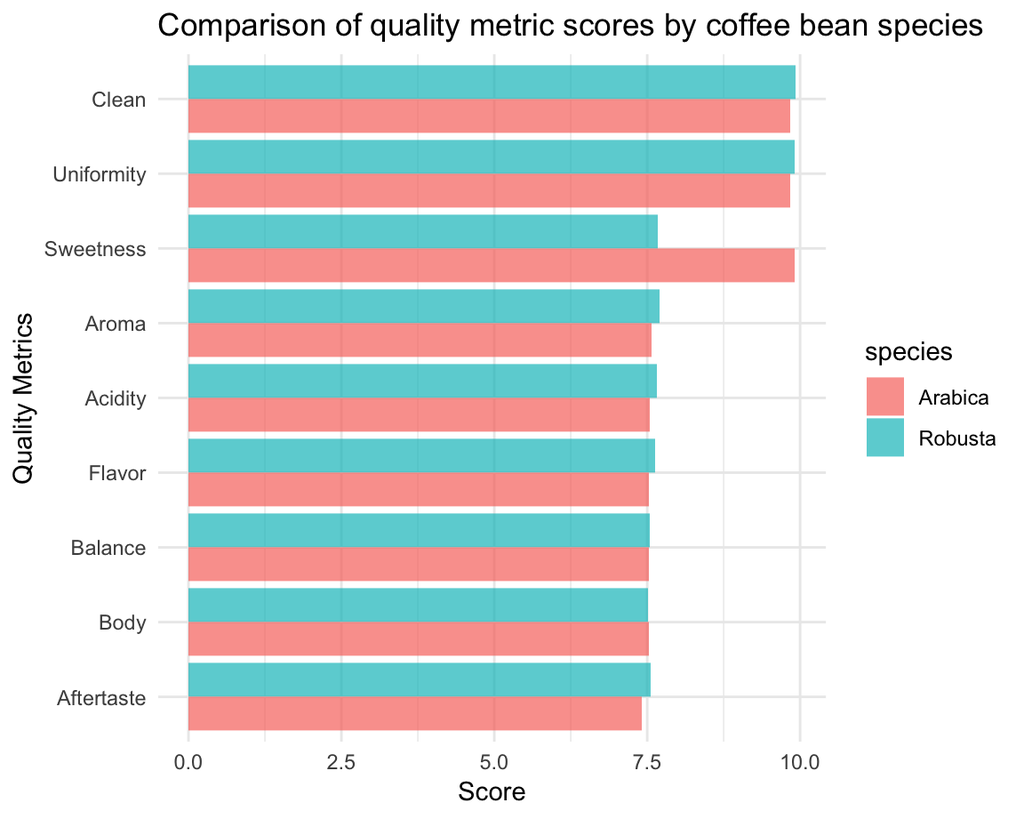